# scplotter to work with 10x Xenium data prepared by Giotto

**The technology.** Xenium is an imaging-based platform: a targeted gene panel is probed in situ and transcripts are detected optically, each one resolved at subcellular coordinates. Alongside the transcript table the instrument produces multi-channel morphology images (DAPI and protein channels) that Giotto can carry as large images, so one object supports both expression and histology views.

**What this notebook covers.** Creating the object from a Xenium output directory, separating negative-control and unassigned codewords into their own feature types, attaching the morphology images, filtering and normalising, PCA/UMAP and Leiden clustering, and then the scplotter repertoire: `SpatDimPlot` over images, `SpatFeaturePlot` on cell metrics, `CellStatPlot`, and `FeatureStatPlot` across marker genes. A final section aggregates cells onto a pseudo-Visium grid to show the same tissue at bin resolution.

**Data.** The 10x Xenium workshop bundle (mini morphology plus transcripts), with the cell and nucleus boundaries shipped by the instrument.

**Before you run.** A Giotto Python environment, and `devtools::load_all()` from the package root so the in-development plotting methods are used.

**Upstream tutorial.**

- https://giotto-suite.github.io/giotto_workshop_2024/xenium-1.html

Go back to scplotter documentation: https://pwwang.github.io/scplotter/

```r
library(Giotto)

# Ensure Giotto can access a python env
genv_exists <- suppressMessages(checkGiottoEnvironment())
print(genv_exists)

python_path <- Sys.getenv("GIOTTO_PYTHON")
Sys.setenv(RETICULATE_PYTHON = python_path)

invisible(capture.output(suppressMessages(set_giotto_python_path(python_path = python_path))))

# library(scplotter)
devtools::load_all()
```

```
Giotto Suite 4.2.3
```

```
[1] TRUE
```

```
ℹ Loading scplotter
```

```r
instrs <- createGiottoInstructions(
    save_dir = "data/Xenium_giotto_workshop_results",
    save_plot = FALSE,
    show_plot = TRUE,
    return_plot = TRUE,
    python_path = python_path
)

feat_types <- c(
    "rna",
    "UnassignedCodeword",
    "NegControlCodeword",
    "NegControlProbe"
)
split_keywords = list(
    c("NegControlProbe"),
    c("UnassignedCodeword"),
    c("NegControlCodeword)"
))
data_path <- "data/Xenium_Giotto_workshop"

# 4. Create the object
# If error, remove <data_path>/morphology_focus/morphology_focus_0000.xml
g <- createGiottoXeniumObject(
    xenium_dir = data_path,
    qv_threshold = 20, # qv of 20 is the default and also what 10x uses
    feat_type = feat_types,
    split_keyword = split_keywords,
    # * if aligned images already converted to .tif, they could be added as named list
    # * instead, see next section
    # load_aligned_images = list(
    #     post_he = c(
    #         "path/to/...he_image.tif",
    #         "path/to/...he_imagealignment.csv"
    #     ),
    #     CD20 = ...,
    #     HER2 = ...,
    #     DAPI = ...
    # ),
    instructions = instrs
)

g <- addSpatialCentroidLocations(g, poly_info = "cell")
g <- addSpatialCentroidLocations(g, poly_info = "nucleus")

force(g)
```

```
python already initialized in this session
 active environment : 'giotto_env'
 python version : 3.10
```

```
Loading transcript level info...
```

```
QV cutoff: 20.000000
 Feature points removed: 80635, out of 559826
```

```
Loading boundary info 'cell'
```

```
No polygon part column detected; assuming single part per cell (part_col =
 NULL)
```

```
Loading boundary info 'nucleus'
```

```
No polygon part column detected; assuming single part per cell (part_col =
 NULL)
```

```
Loading 10x pre-aggregated expression...
```

```
Setting expression [cell][rna] raw
```

```
Setting expression [cell][NegControlProbe] raw
```

```
Setting expression [cell][NegControlCodeword] raw
```

```
Setting expression [cell][UnassignedCodeword] raw
```

```
Loading feature metadata...
```

```
loading image as 'bound1'
```

```
loading image as 'bound2'
```

```
loading image as 'bound3'
```

```
loading image as 'bound4'
```

```
calculating centroids
```

```
done
```

```
Start centroid calculation for polygon information
 layer: cell
```

```
> spatial locations for polygon information layer " cell " and name " raw "
 already exists and will be replaced
```

```
Start centroid calculation for polygon information
 layer: nucleus
```

```
> spatial locations for polygon information layer " nucleus " and name " raw "
 already exists and will be replaced
```

```
An object of class giotto
>Active spat_unit:  cell
>Active feat_type:  rna
dimensions    : 377, 7655 (features, cells)
[SUBCELLULAR INFO]
polygons      : cell nucleus
features      : rna UnassignedCodeword NegControlCodeword NegControlProbe
[AGGREGATE INFO]
expression -----------------------
  [cell][rna] raw
  [cell][NegControlProbe] raw
  [cell][NegControlCodeword] raw
  [cell][UnassignedCodeword] raw
spatial locations ----------------
  [cell] raw
  [nucleus] raw
attached images ------------------
images      : 4 items...


Use objHistory() to see steps and params used
```

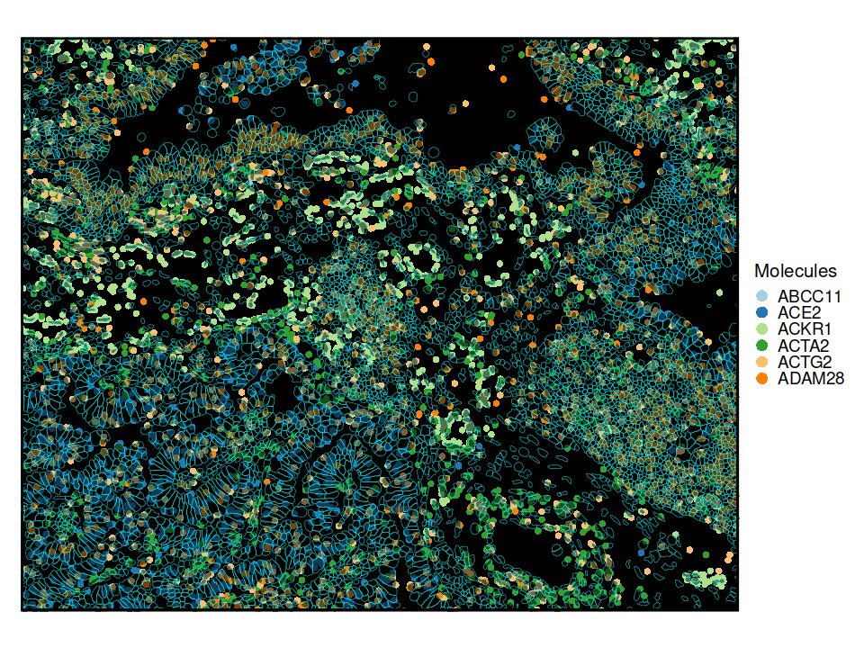

```r
# Simple Visualization
options(repr.plot.width = 8, repr.plot.height = 6)

SpatDimPlot(
    g,
    image = "black",
    # put shapes at last
    layers = c("image", "points", "shapes"),
    features = head(featIDs(g)),
    shapes_border_color = "cyan",
    shapes_border_size = 0.1,
    shapes_fill_by = "black"
)
```

```r
x <- importXenium(data_path)
x$filetype$expression <- "mtx" # change to mtx instead of .h5 which is not in the mini dataset

ex <- x$load_expression()
featType(ex)

featType(ex[[2]]) <- c("NegControlProbe")
featType(ex[[3]]) <- c("NegControlCodeword")
featType(ex[[4]]) <- c("UnassignedCodeword")
force(ex)

g2 <- g
# append the expression info
g2 <- setGiotto(g2, ex)

# load cell metadata
cx <- x$load_cellmeta()
g2 <- setGiotto(g2, cx)

force(g2)
```

```
Loading 10x pre-aggregated expression...
```

1. 'rna'

2. 'NegControlProbe'

3. 'NegControlCodeword'

4. 'UnassignedCodeword'

```
[[1]]
An object of class exprObj : "raw"
spat_unit : "cell"
feat_type : "rna"
provenance: cell

contains:
377 x 7655 sparse Matrix of class "dgTMatrix"

ABCC11 . . . . . . . . . . . . . ......
ACE2   . . . . . . . . . . . . . ......
ACKR1  . . . . . . . . . . . . . ......

 ........suppressing 7642 columns and 371 rows

VSIG4 . . . . . . . . . . . . . ......
VWA5A . . . . . 2 . 1 . 1 . . . ......
VWF   . . . 1 1 . . . . . . . . ......

 First four colnames:
 caijolig-1 caikcgdg-1 cailegle-1
 cailnfaf-1

[[2]]
An object of class exprObj : "raw"
spat_unit : "cell"
feat_type : "NegControlProbe"
provenance: cell

contains:
13 x 7655 sparse Matrix of class "dgTMatrix"

NegControlProbe_00042 . . . . . . . . . . . . . ......
NegControlProbe_00035 . . . . . . . . . . . . . ......
NegControlProbe_00034 . . . . . . . . . . . . . ......

 ........suppressing 7642 columns and 7 rows

NegControlProbe_00013 . . . . . . . . . . . . . ......
NegControlProbe_00004 . . . . . . . . . . . . . ......
```

[output cut: 35 more lines]

```
25 x 7655 sparse Matrix of class "dgTMatrix"

UnassignedCodeword_0006 . . . . . . . . . . . . . ......
UnassignedCodeword_0401 . . . . . . . . . . . . . ......
UnassignedCodeword_0409 . . . . . . . . . . . . . ......

 ........suppressing 7642 columns and 19 rows

UnassignedCodeword_0496 . . . . . . . . . . . . . ......
UnassignedCodeword_0498 . . . . . . . . . . . . . ......
UnassignedCodeword_0499 . . . . . . . . . . . . . ......

 First four colnames:
 caijolig-1 caikcgdg-1 cailegle-1
 cailnfaf-1
```

```
> raw already exists and will be replaced with new values
```

```
Setting expression [cell][rna] raw
```

```
> raw already exists and will be replaced with new values
```

```
Setting expression [cell][NegControlProbe] raw
```

```
> raw already exists and will be replaced with new values
```

```
Setting expression [cell][NegControlCodeword] raw
```

```
> raw already exists and will be replaced with new values
```

```
Setting expression [cell][UnassignedCodeword] raw
```

```
Loading 10X cell metadata...
```

```
> Cell metadata for spat_unit " cell " and feat_type " rna " already exists and
 will be replaced with new metadata.
```

```
Setting cell metadata [cell][rna]
```

```
An object of class giotto
>Active spat_unit:  cell
>Active feat_type:  rna
dimensions    : 377, 7655 (features, cells)
[SUBCELLULAR INFO]
polygons      : cell nucleus
features      : rna UnassignedCodeword NegControlCodeword NegControlProbe
[AGGREGATE INFO]
expression -----------------------
  [cell][rna] raw
  [cell][NegControlProbe] raw
  [cell][NegControlCodeword] raw
  [cell][UnassignedCodeword] raw
spatial locations ----------------
  [cell] raw
  [nucleus] raw
attached images ------------------
images      : 4 items...


Use objHistory() to see steps and params used
```

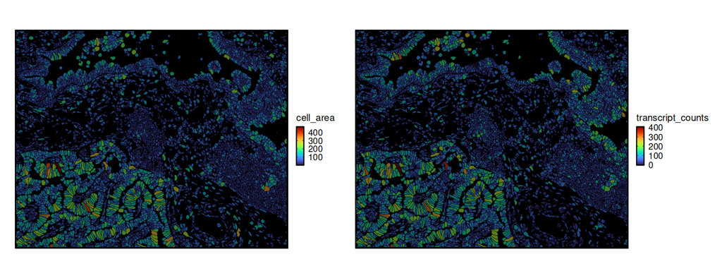

```r
options(repr.plot.width = 13, repr.plot.height = 5)
p1 <- SpatFeaturePlot(
    g2,
    image = "black",
    points = FALSE,  # don't show points
    shapes_border_size = 0.1,
    shapes_fill_by = "cell_area"
)
p2 <- SpatFeaturePlot(
    g2,
    image = "black",
    points = FALSE,  # don't show points
    shapes_border_size = 0.1,
    shapes_fill_by = "transcript_counts"
)
p1 + p2
```

```r
img_paths <- c(
    sprintf("data/Xenium_Giotto_workshop/morphology_focus/morphology_focus_%04d.tif", 0:3),
    "data/Xenium_Giotto_workshop/he_mini.tif"
)

img_list <- createGiottoLargeImageList(
    img_paths,
    # naming is based on the channel metadata above
    names = c("DAPI", "18S", "ATP1A1/CD45/E-Cadherin", "alphaSMA/Vimentin", "HE"),
    use_rast_ext = TRUE,
    verbose = FALSE
)

# make some images brighter
img_list[[1]]@max_window <- 5000
img_list[[2]]@max_window <- 5000
img_list[[3]]@max_window <- 5000

# append images to gobject
g <- setGiotto(g, img_list)
```

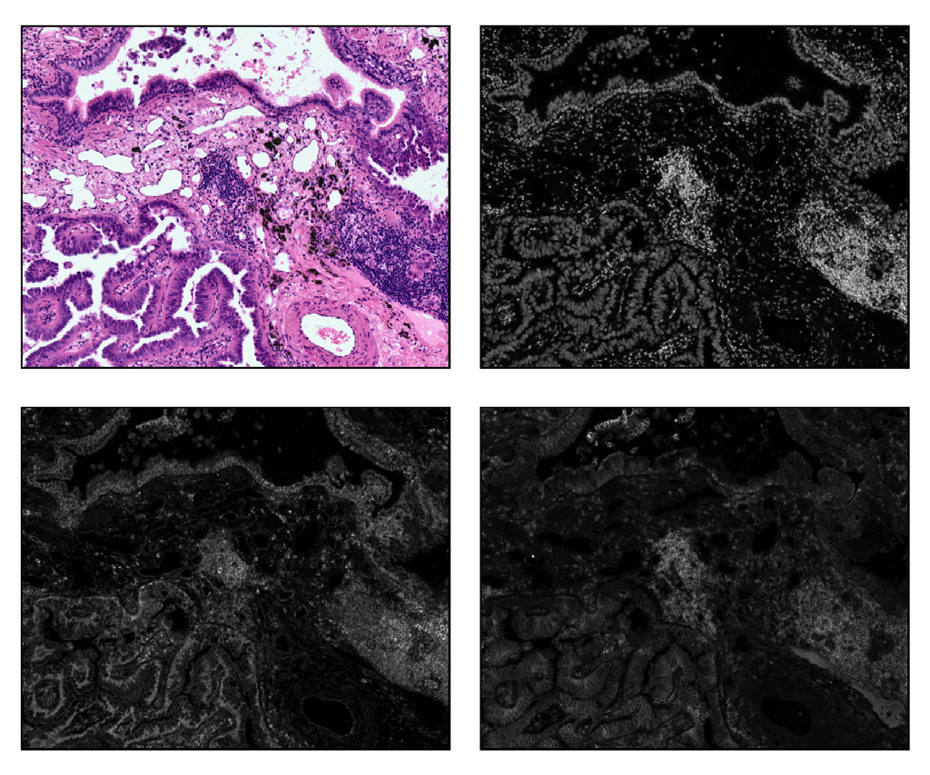

```r
options(repr.plot.width = 12, repr.plot.height = 10)
p1 <- SpatDimPlot(g, image = "HE", points = FALSE)
p2 <- SpatDimPlot(g, image = "DAPI", shapes_feat_type = "nucleus", points = FALSE)
p3 <- SpatDimPlot(g, image = "18S", points = FALSE)
p4 <- SpatDimPlot(g, image = "ATP1A1/CD45/E-Cadherin", shapes_feat_type = "nucleus",
    points = FALSE)

(p1 + p2) / (p3 + p4)
```

```r
g <- addStatistics(g2, expression_values = "raw")
g <- normalizeGiotto(g)
g <- filterGiotto(g,
    expression_threshold = 1,
    feat_det_in_min_cells = 1,
    min_det_feats_per_cell = 5
)
# overwrite original results with those for normalized values
g <- addStatistics(g)
```

```
calculating statistics for "raw" expression
```

```
first scale feats and then cells
```

```
Setting expression [cell][rna] normalized
```

```
Setting expression [cell][rna] scaled
```

```
completed 1: preparation
```

```
completed 2: subset expression data
```

```
completed 3: subset spatial locations
```

```
completed 4: subset cell metadata
```

```
completed 5: subset feature metadata
```

```
completed 6: subset spatial network(s)
```

```
completed 7: subsetted dimension reductions
```

```
completed 8: subsetted nearest network(s)
```

```
completed 9: subsetted spatial enrichment results
```

```
for cell
```

```
--> cell found back in polygon layer: cell
```

```
for nucleus
```

```
completed 10: subsetted spatial information data
```

```
subset feature info: rna
```

```
completed 11: subsetted spatial feature data
```

```
Feature type:  rna
Number of cells removed:  69  out of  7655
Number of feats removed:  0  out of  377
```

```
calculating statistics for "normalized" expression
```

```
feat statistics has already been applied once; overwriting
```

```
cells statistics has already been applied once; overwriting
```

```
These column names were already used: area
 and will be overwritten
```

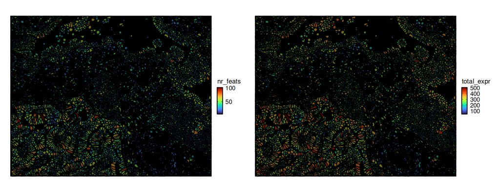

```r
options(repr.plot.width = 13, repr.plot.height = 5)
p1 <- SpatFeaturePlot(
    g,
    image = "black",
    points = FALSE,  # don't show points
    shapes_fill_by = "nr_feats"
)
p2 <- SpatFeaturePlot(
    g,
    image = "black",
    points = FALSE,  # don't show points
    shapes_fill_by = "total_expr"
)
p1 + p2
```

```r
g <- runPCA(g, feats_to_use = NULL)
g <- runUMAP(g,
    dimensions_to_use = seq(15),
    n_neighbors = 40 # default
)
g <- createNearestNetwork(g,
    dimensions_to_use = seq(15),
    k = 40
)

# takes roughly 1 min to run
g <- doLeidenCluster(g)

# igraph-based leiden returns integer labels; keep them categorical so that
# shapes_fill_by / group_by use a discrete scale instead of a continuous one
g@cell_metadata$cell$rna$leiden_clus <- factor(g@cell_metadata$cell$rna$leiden_clus)
```

```
Setting dimension reduction [cell][rna] pca
```

```
Setting dimension reduction [cell][rna] umap
```

```
As of Giotto 4.2.3 doLeidenCluster() works via {igraph}
 For the python implementation, use doLeidenClusterPython()
 This message appears once per session.
```

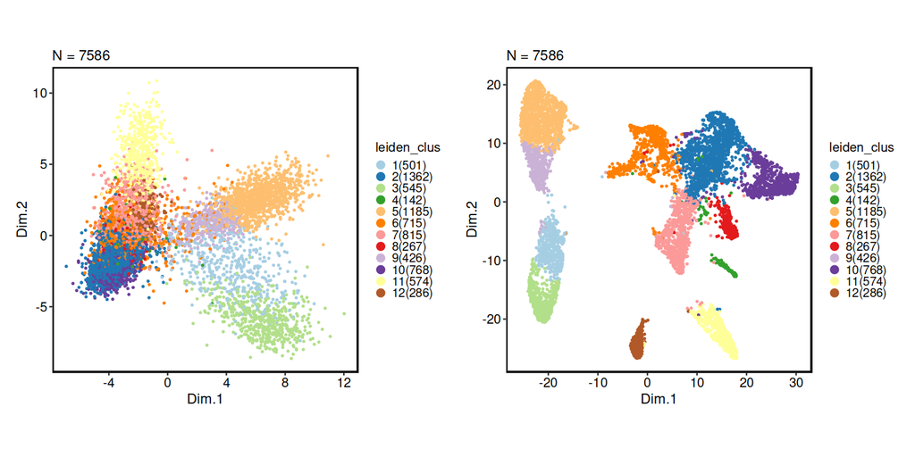

```r
options(repr.plot.width = 12, repr.plot.height = 6)

p1 <- CellDimPlot(g, group_by = "leiden_clus", spat_unit = "cell", reduction = "pca")
p2 <- CellDimPlot(g, group_by = "leiden_clus", spat_unit = "cell", reduction = "umap")

p1 + p2
```

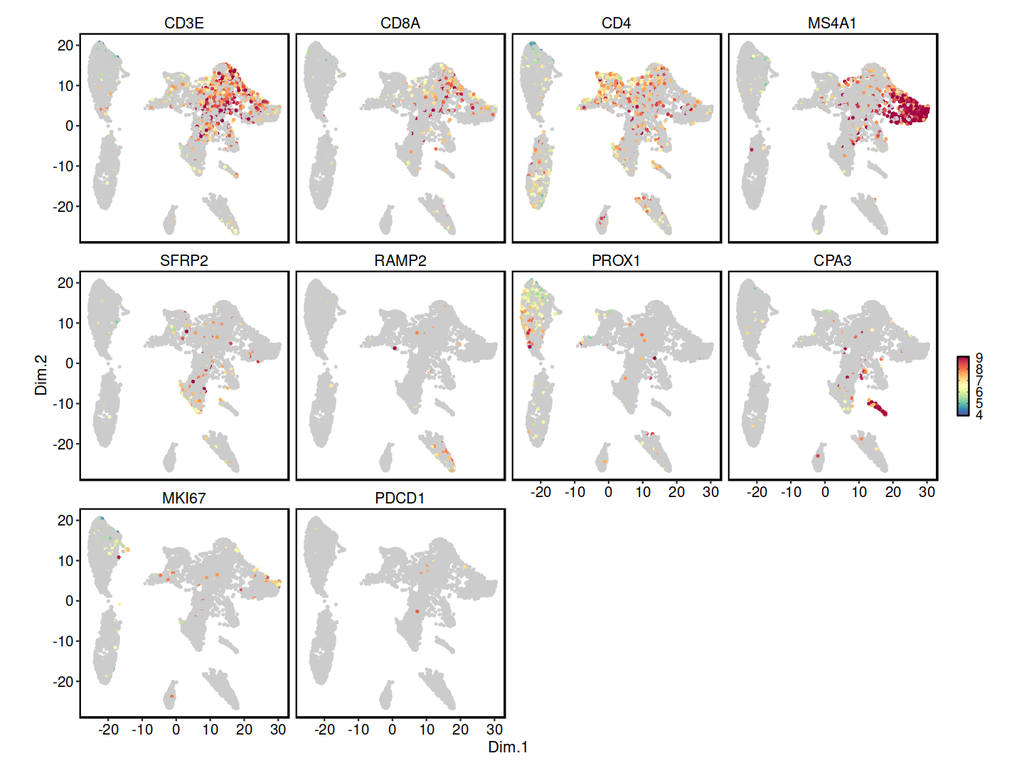

```r
options(repr.plot.width = 12, repr.plot.height = 9)

FeatureStatPlot(
    g,
    features = c(
        "CD3E", "CD8A", "CD4", # T cell
        "MS4A1", # B
        "SFRP2", # CAF (mesenchymal)
        "RAMP2", # endothelial
        "PROX1", # LEC (lymphatic endothelial cell)
        "CPA3", # mast cell
        "MKI67", # epithelial/cancer
        "PDCD1" # PD1
    ),
    layer = "normalized",
    bg_cutoff = 0,  # unexpressed (<=0) cells stay grey instead of taking colour
    upper_quantile = 0.9,
    spat_unit = "cell",
    reduction = "umap",
    plot_type = "dim"
)
```

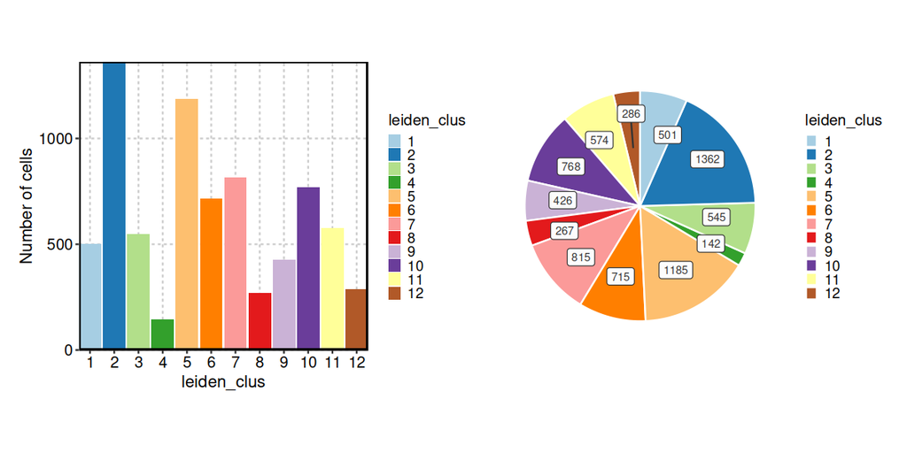

```r
options(repr.plot.width = 10, repr.plot.height = 5)

p1 <- CellStatPlot(g, spat_unit = "cell", ident = "leiden_clus")
p2 <- CellStatPlot(g, spat_unit = "cell", ident = "leiden_clus", plot_type = "pie")

p1 + p2
```

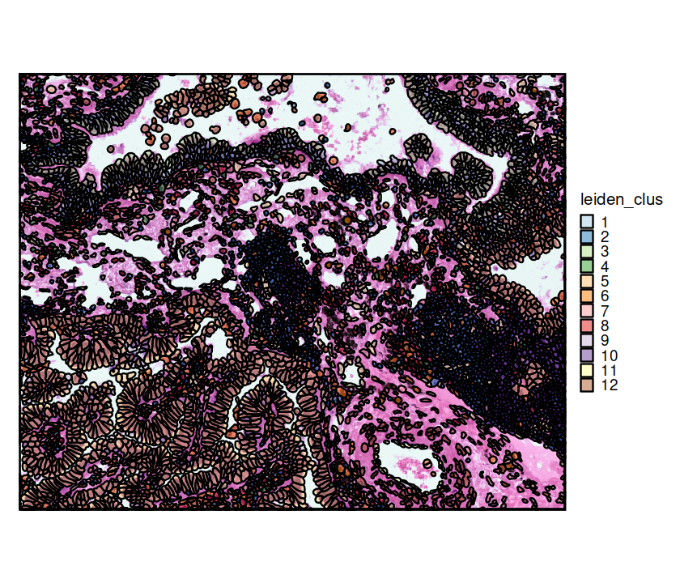

```r
options(repr.plot.width = 7, repr.plot.height = 6)

g <- setGiotto(g, img_list)
SpatDimPlot(
    g,
    image = "HE",
    points = FALSE,  # don't show points
    shapes_fill_by = "leiden_clus"
)
```

```r
pvis <- makePseudoVisium(
    extent = ext(g, prefer = c("polygon", "points"), all_data = TRUE),
     # all_data = TRUE is the default
    micron_size = 1
)

g <- setGiotto(g, pvis)
g <- addSpatialCentroidLocations(g, poly_info = "pseudo_visium")
activeSpatUnit(g) <- "pseudo_visium"

g <- calculateOverlap(g,
    spatial_info = "pseudo_visium",
    feat_info = "rna"
)

g <- overlapToMatrix(g)

g <- filterGiotto(g,
    expression_threshold = 1,
    feat_det_in_min_cells = 1,
    min_det_feats_per_cell = 100
)

g <- normalizeGiotto(g)
g <- addStatistics(g)
g <- createSpatialNetwork(g, method = "Delaunay")
```

```
86 polygons generated
```

```
Setting polygon info [pseudo_visium]
```

```
Start centroid calculation for polygon information
 layer: pseudo_visium
```

```
completed 1: preparation
```

```
completed 2: subset expression data
```

```
completed 3: subset spatial locations
```

```
completed 4: subset cell metadata
```

```
completed 5: subset feature metadata
```

```
completed 6: subset spatial network(s)
```

```
completed 7: subsetted dimension reductions
```

```
completed 8: subsetted nearest network(s)
```

```
completed 9: subsetted spatial enrichment results
```

```
for cell
```

```
for nucleus
```

```
for pseudo_visium
```

```
--> pseudo_visium found back in polygon layer: pseudo_visium
```

```
completed 10: subsetted spatial information data
```

```
subset feature info: rna
```

```
completed 11: subsetted spatial feature data
```

```
Feature type:  rna
Number of cells removed:  2  out of  86
Number of feats removed:  7  out of  384
```

```
first scale feats and then cells
```

```
Setting expression [pseudo_visium][rna] normalized
```

```
Setting expression [pseudo_visium][rna] scaled
```

```
calculating statistics for "normalized" expression
```

```
Setting spatial network [pseudo_visium] Delaunay_network
```

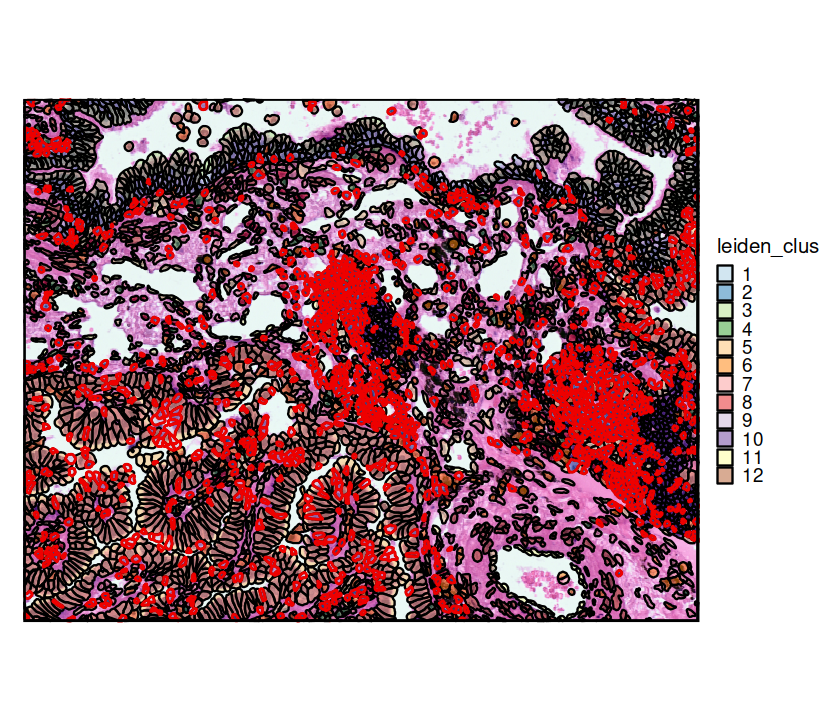

```r
options(repr.plot.width = 7, repr.plot.height = 6)
SpatDimPlot(
    g,
    image = "HE",
    points = FALSE,  # don't show points
    shapes_fill_by = "leiden_clus",
    shapes_highlight = 'leiden_clus %in% c("2", "9")',
    shapes_highlight_color = "red2",
    shapes_highlight_stroke = 0.1
)
```

```
ℹ Loading scplotter
```

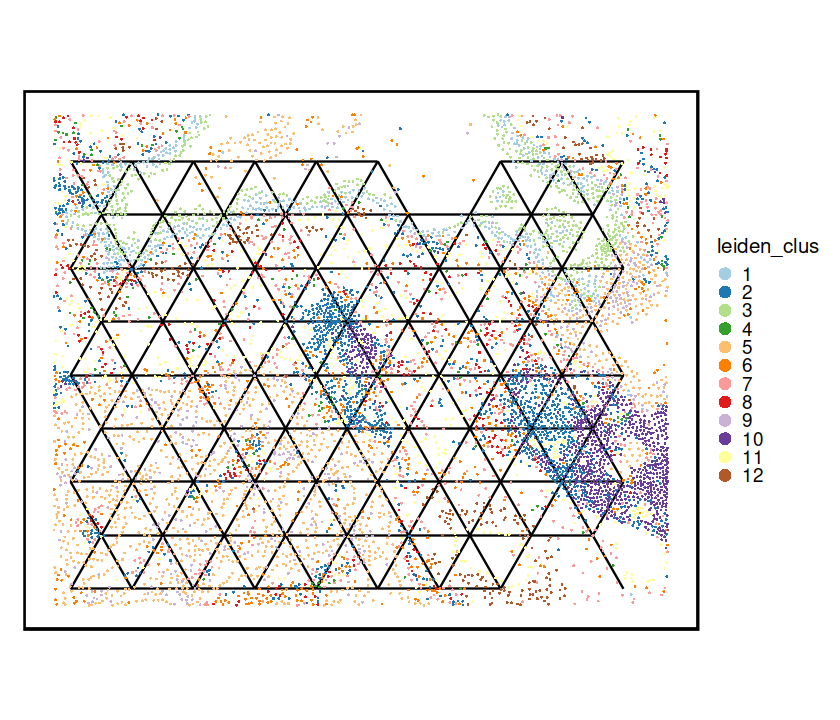

```r
options(repr.plot.width = 7, repr.plot.height = 6)
devtools::load_all()
p <- SpatDimPlot(
    g,
    group_by = "leiden_clus",
    graph = "pseudo_visium:Delaunay_network",
    spat_unit = "cell",
    points_raster = FALSE,
    points_size = 0.2,
    points_edge_alpha = 1,
    points_edge_color = "black",
    points_edge_size = 0.5
)
p
```

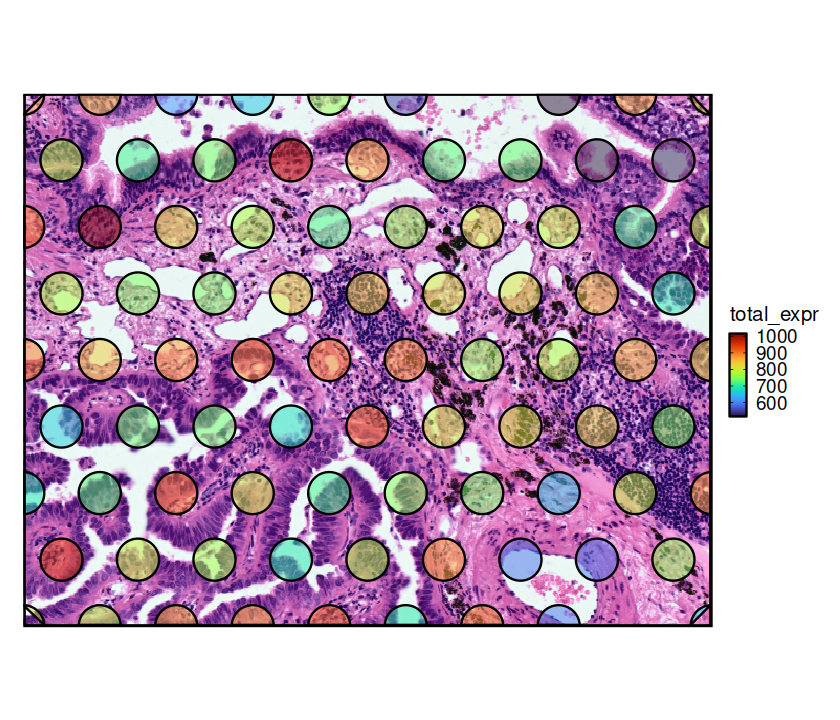

```r
options(repr.plot.width = 7, repr.plot.height = 6)
SpatFeaturePlot(
    g,
    image = "HE",
    points = FALSE,  # don't show points
    shapes_fill_by = "total_expr",
    shapes_feat_type = "pseudo_visium"
)
```

```r
x <- capture.output(print(x))
# hide the BLAS/LAPACK paths
x <- x[!startsWith(x, "BLAS/LAPACK:")]
cat(paste(x, collapse = "\n"))
```

[output not shown]